# R Notebook

```r
df = read.table("had.txt", sep = "")
df = df[sample(1:nrow(df)), ]
label = df['V7']
features = df[,1:6]

split = sample(c(rep(0, 0.8 * nrow(label)), rep(1, 0.2 * nrow(label))))
train_label = label[split == 0,]
test_label = label[split == 1,]
train_features = features[split == 0,]
test_features = features[split == 1,]

write.csv(x=train_label, file="train_label.txt")
write.csv(x=test_label, file="test_label.txt")
write.csv(x=train_features, file="train_features.txt")
write.csv(x=test_features, file="test_features.txt")

data = data.frame(train_features, train_label)
model <- lm(train_label~V1+V2+V3+V4+V5+V6, data=data)
summary(model)
```

```
Call:
lm(formula = train_label ~ V1 + V2 + V3 + V4 + V5 + V6, data = data)

Residuals:
     Min       1Q   Median       3Q      Max
-2.17375 -0.60373 -0.06404  0.65121  1.85461

Coefficients:
             Estimate Std. Error t value Pr(>|t|)
(Intercept)  2.538850   0.552055   4.599 6.93e-06 ***
V1          -0.019117   0.006211  -3.078  0.00233 **
V2          -0.635336   0.117723  -5.397 1.65e-07 ***
V3           0.414745   0.054267   7.643 5.32e-13 ***
V4          -0.006378   0.003308  -1.928  0.05508 .
V5          -0.002088   0.001093  -1.910  0.05733 .
V6          -0.021914   0.153066  -0.143  0.88628
---
Signif. codes:  0 ‘***’ 0.001 ‘**’ 0.01 ‘*’ 0.05 ‘.’ 0.1 ‘ ’ 1

Residual standard error: 0.8302 on 236 degrees of freedom
Multiple R-squared:  0.3223,    Adjusted R-squared:  0.305
F-statistic:  18.7 on 6 and 236 DF,  p-value: < 2.2e-16
```

بخش resuduals تفاوت داده‌ها را با داده‌های تخمین زده شده نشان می‌دهد و شامل میانگین مینیمم ماکسیمم، میانه و چارک‌هاست و میتوانیم بفهمیم چقدر داده ما متقارن است. در حالت کلی دوست داریم متقارن و میانه برابر صفر باشد..

Coefficients — Estimate ضرایب به دست آمده در مدل را نشان می‌دهد.

Coefficients — Std. Error تخمینی از standard deviation ضرایب به دست آمده است.

Coefficients — t value ضرایب به دست آمده تقسیم بر standard error است و دوست داریم که این مقادیر زیاد باشند زیرا نشان می‌دهد که ارور کم است.

Coefficients — Pr(>|t|) مقادیری است که توسط t value و t distribution به دست میآید. و می تواند این اطمینان را دهد که ضرایب صفر نیستند. اگر کمتر از 0.05 باشد.

Residual Standard Error نشان می‌دهد که مدل چقدر خوب روی دیتای ما فیت شده است. نمودی از اختلاف مقادیر به دست آمده از خط است.

Multiple R-squared and Adjusted R-squared مقدار اول نشان می‌دهد چقدر مدل خوب فیت شده است. و مقدار دوم برای multiple regression کاربرد دارد.

F-statistic and p-value نشان میدهد که فرض صفر باید رد شود یا خیر که فرض صفر این است که رابطه‌ای بین متغیر های مستقل و وابسته وجود دارد یا خیر. در بیشتر مواقع مقدار کمتر از ۰.۰۵ نشان میدهد که حداقل یک ضریب وجود دارد که صفر نباشد.

```r
coeff = data.frame(model$coefficients)
Vec = c(rep(1, nrow(test_features)))
test_features = data.frame(Vec, test_features)

predictions = as.matrix(test_features) %*% as.matrix(coeff)
acc = vector()


for (i in 1:nrow(predictions)) {
    if (predictions[i] > 0) {
      pred_vec = c(pred_vec, 1)
    }
    else
      pred_vec = c(pred_vec, -1)

  }
  count = 0
  for (i in 1:nrow(predictions)) {
    if (pred_vec[i] == test_label[i])
      count = count + 1
  }
  count / nrow(test_features)
```

```
[1] 0.5
```

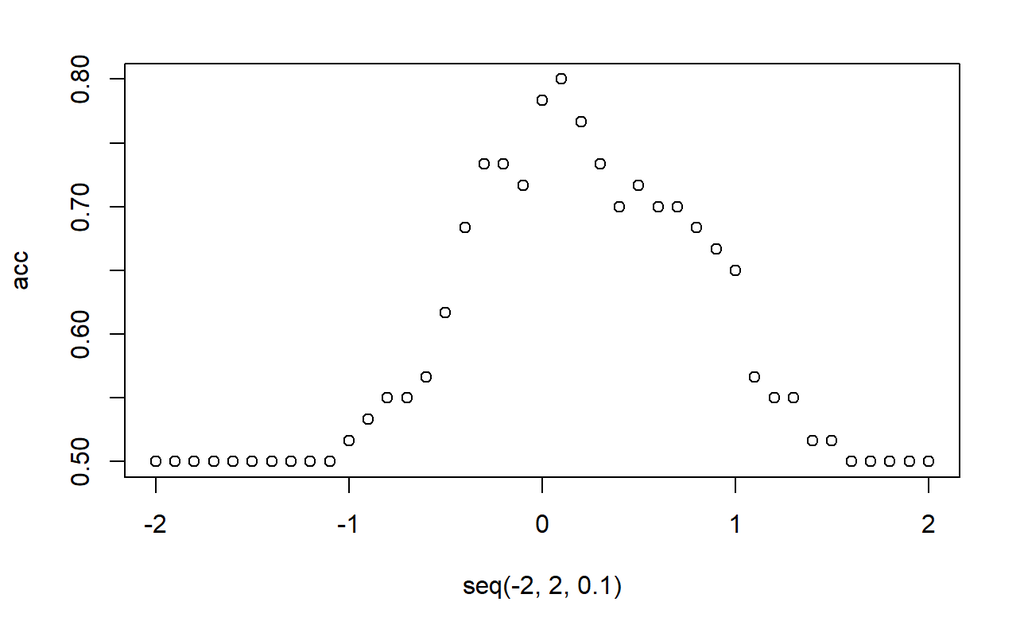

```r
for (alpha in seq(-2, 2, 0.1)) {
  pred_vec = vector()
  for (i in 1:nrow(predictions)) {
    if (predictions[i] > alpha) {
      pred_vec = c(pred_vec, 1)
    }
    else
      pred_vec = c(pred_vec, -1)

  }
  count = 0
  for (i in 1:nrow(predictions)) {
    if (pred_vec[i] == test_label[i])
      count = count + 1
  }
  acc = c(acc, count / nrow(test_features))
}
plot(seq(-2, 2, 0.1), acc)
```

```r
which.max(acc)
```

```
[1] 22
```

```r
print(-2 + which.max(acc) * 0.1)
```

```
[1] 0.2
```